# 99 Article Illustrations

Anders Sundelin

2024-04-05

## Collecting illustrations and data for the article

```r
stopifnot(dir.exists(params$cache))
stopifnot(dir.exists(params$output))
```

```r
set.seed(12345)
source("ingest_data.R")
d <- data |> select(y=INTROD,
                    A=A,
                    C=C,
                    D=D,
                    R=R,
                    team=committerteam,
                    repo=repo)
```

```r
M0_file <- "added-M_intercepts_only.rds"
M1_file <- "added-M_added_removed_lines.rds"
M2_file <- "added-M_pop_A_team_team_repo_RDC_zi_sd025_gamma05.rds"

MODELS <- c(cachefile(M0_file), cachefile(M1_file), cachefile(M2_file))
lapply(MODELS, function(m) { print(m); stopifnot(file.exists(m)) } )
```

```
## [1] "../.cache/added-M_intercepts_only.rds"
## [1] "../.cache/added-M_added_removed_lines.rds"
## [1] "../.cache/added-M_pop_A_team_team_repo_RDC_zi_sd025_gamma05.rds"
```

```r
reloo_M0_f <- cachefile(paste0("reloo-", M0_file))
reloo_M1_f <- cachefile(paste0("reloo-", M1_file))
reloo_M2_f <- cachefile(paste0("reloo-", M2_file))
RELOO <- c(reloo_M0_f, reloo_M1_f, reloo_M2_f)
lapply(RELOO, function(m) { print(m); stopifnot(file.exists(m)) } )
```

```
## [1] "../.cache/reloo-added-M_intercepts_only.rds"
## [1] "../.cache/reloo-added-M_added_removed_lines.rds"
## [1] "../.cache/reloo-added-M_pop_A_team_team_repo_RDC_zi_sd025_gamma05.rds"
```

```r
reloo_M0 <- readRDS(reloo_M0_f)
reloo_M1 <- readRDS(reloo_M1_f)
reloo_M2 <- readRDS(reloo_M2_f)

ppc_M2_f <- cachefile(paste0("ppc-", M2_file))
stopifnot(file.exists(ppc_M2_f))
ppc_M2 <- readRDS(ppc_M2_f)

M0 <- readRDS(cachefile(M0_file))
M1 <- readRDS(cachefile(M1_file))
M2 <- readRDS(cachefile(M2_file))

RM0_file <- "removed-M_intercepts_only.rds"
stopifnot(file.exists(cachefile(RM0_file)))

RM0 <- readRDS(cachefile(RM0_file))
```

```r
loo_M0 <- loo(M0)
loo_M1 <- loo(M1)
loo_M2 <- loo(M2)
loo_compare(loo_M0, loo_M1, loo_M2)
```

```
##    elpd_diff se_diff
## M2     0.0       0.0
## M1  -209.0      24.9
## M0 -2220.3      76.6
```

These are the comparisons for the LOO (approximated PSIS) comparison

## Table 2

When we have performed the reloo (recomputed the exact, not approximated, LOO-CV once for each problematic observation), we get similar, but more exact numbers. We report these, more exact comparisons, in the paper.

```r
loo_compare(list(M0=reloo_M0, M1=reloo_M1, M2=reloo_M2))
```

```
##    elpd_diff se_diff
## M2     0.0       0.0
## M1  -205.9      24.7
## M0 -2217.5      77.0
```

## Figure 1 - Causal DAG

```r
coords <- data.frame(name=c("TEAM", "KNOW", "CLEAN", "DUP", "COMP", "ADD", "REM", "INTR"),
                     x=c(        0,    0.2,     0.4,   0.4,   0.35,   0.55,   0.38, 1.0),
                     y=c(    -0.03,    0.2,   -0.08,   0.2,   0.03,   0.07,   -0.2, 0))
dagified <- dagify( INTR ~ REM + COMP + ADD + DUP + TEAM,
                    COMP ~ TEAM + DUP,
                    REM ~ TEAM + CLEAN,
                    ADD ~ COMP + CLEAN + KNOW + DUP,
                    DUP ~ TEAM,
                    CLEAN ~ TEAM,
                    KNOW ~ TEAM + DUP + COMP,
                    exposure = "TEAM",
                    outcome = "INTR",
                    latent = c("CLEAN", "KNOW"),
                    coords=coords)
(p <- ggdag_status(dagified) + theme_dag() + theme(legend.position="bottom") + guides(color = guide_legend(override.aes = list(size = 2), title=NULL, direction="horizontal", nrow = 1))
)
```

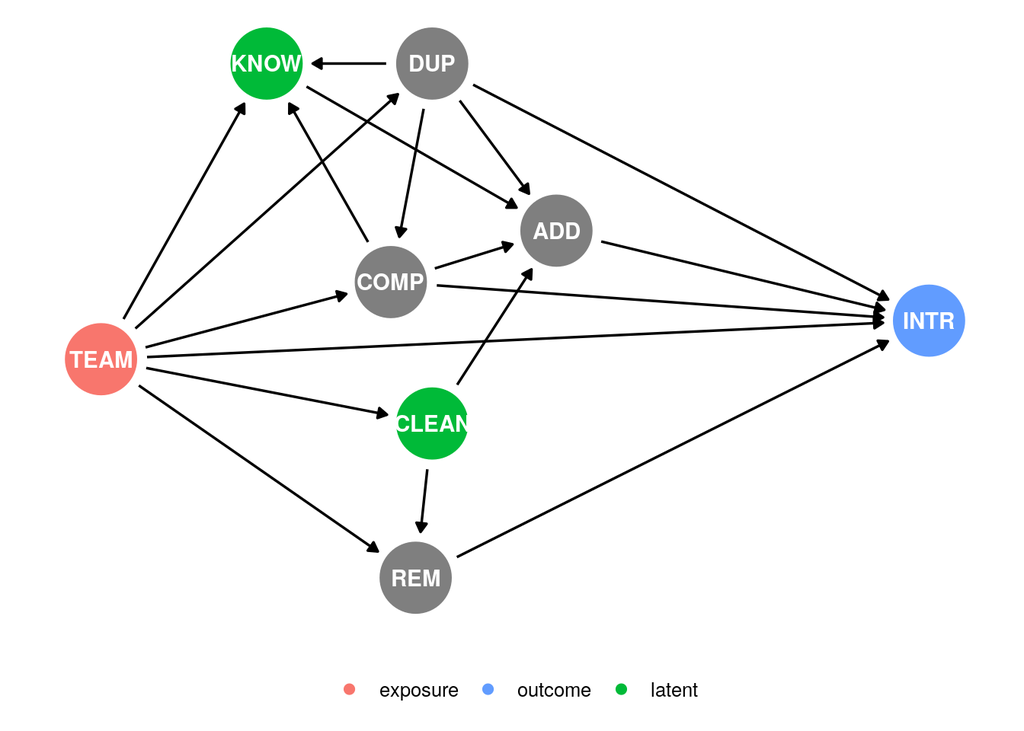

```r
figsave("99-causal-dag.pdf", p)
```

## Figure 2 - Prior Predictive Checks

Plotting the 95th percentile of prior predictions, versus the 99th. The scales are different on the x and y axes, as it is more likely to find extreme values at the higher percentiles.

```r
yrep <- posterior_predict(ppc_M2) # predicting with other data points are supported via the newdata argument
```

```r
(p <- ppc_stat_2d(d$y, yrep, stat = c("q95", "q99")) + theme(legend.position="bottom") #+ ggtitle("Prior predicted Q95 vs Q99")
)
```

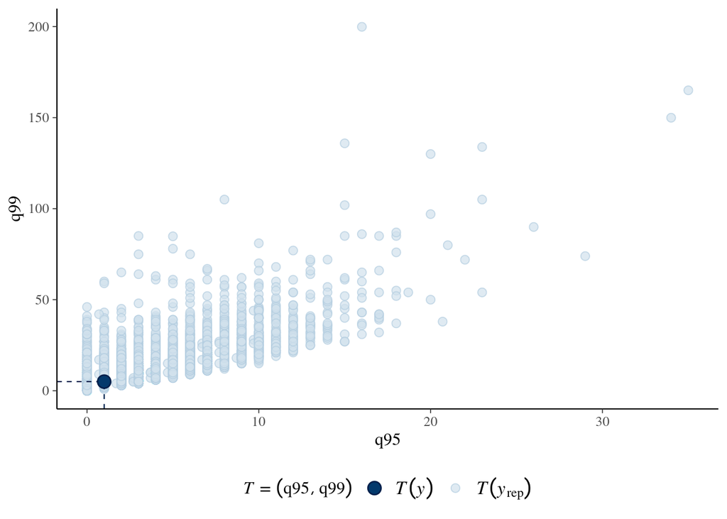

```r
figsave("99-prior_predictive_q95_vs_q99.pdf", p)
```

## Figure 3 - Rootogram

Rootogram, full scale

```r
(rootogram <- pp_check(M2, type = "rootogram", style="suspended")
)
```

```
## Using all posterior draws for ppc type 'rootogram' by default.
```

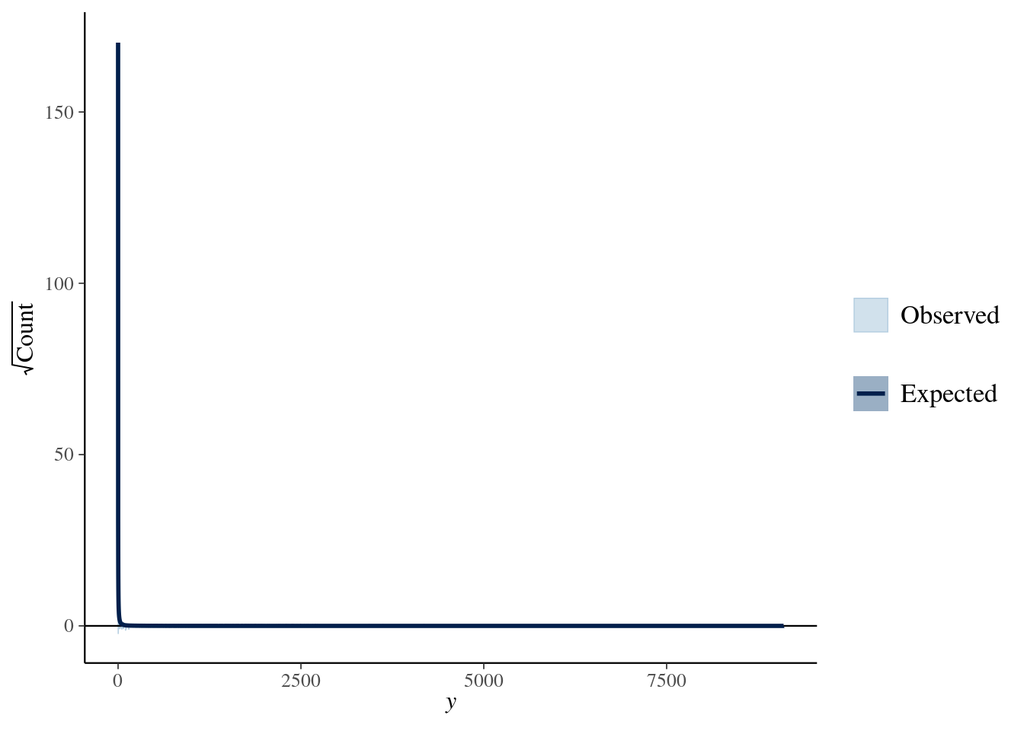

Rootogram, sized according to reasonable (observed) values.

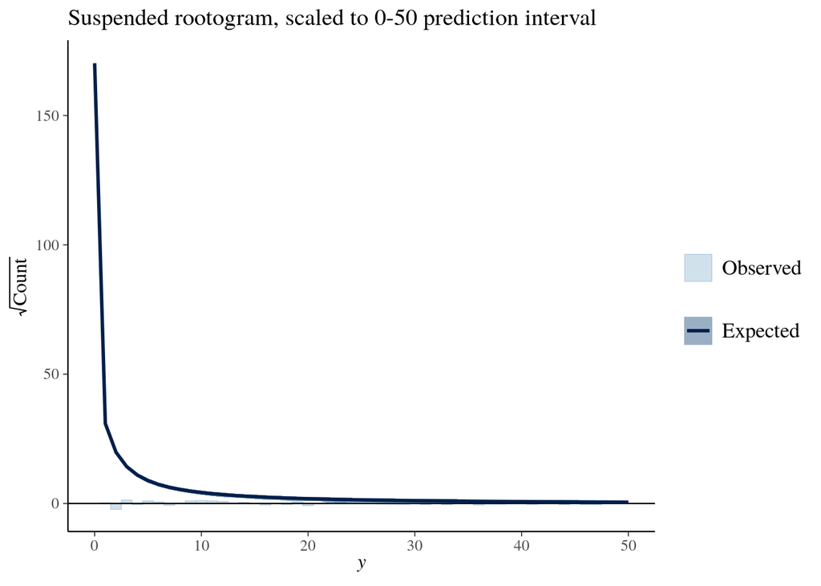

```r
rootogram + scale_x_continuous(limits=c(0,50)) + ggtitle("Suspended rootogram, scaled to 0-50 prediction interval")
```

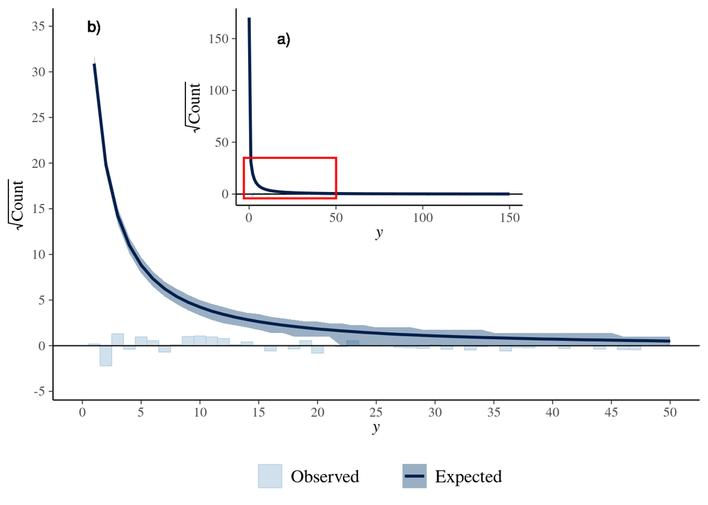

```r
topleft=data.frame(x=c(0, 0),
                   xend=c(17, 17),
                   y=c(35, -4),
                   yend=c(22, 17))
main.plot <- rootogram + scale_x_continuous(limits = c(0,50), breaks = seq(from=0, to=50, by=5)) + scale_y_continuous(limits = c(-4,35), breaks = c(-5, 0, 5, 10, 15, 20, 25, 30, 35)) + geom_text(x=1, y=35, label="b)") + theme(legend.position="bottom")
inset.plot <- rootogram + theme(legend.position = "none") + scale_x_continuous(limits = c(0,150))  + geom_text(x=20, y=150, label="a)") + geom_rect(xmin=-3, xmax=50, ymin=-4, ymax=35, color="red", fill=NA)
(p <- ggdraw() + draw_plot(main.plot) + draw_plot(inset.plot, x=0.25, y=.5, width = 0.5, height = 0.5)
)
```

```r
figsave("99-rootogram.pdf", p)
```

## Figure 4 - Posterior proportion of zeros

```r
yrep <- posterior_predict(M2)
```

```r
(p <- ppc_stat(y = d$y, yrep, stat = function(y) mean(y == 0))
)
```

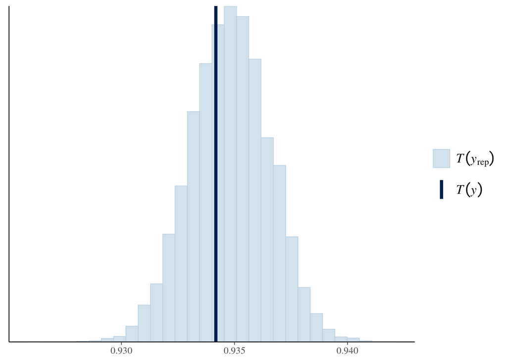

```r
figsave("99-posterior_prop_zeros.pdf", p)
```

## Figure 6 - Observed proportion of file changes

As we do not know to which team the Unknown authors belong, they are excluded from the plot.

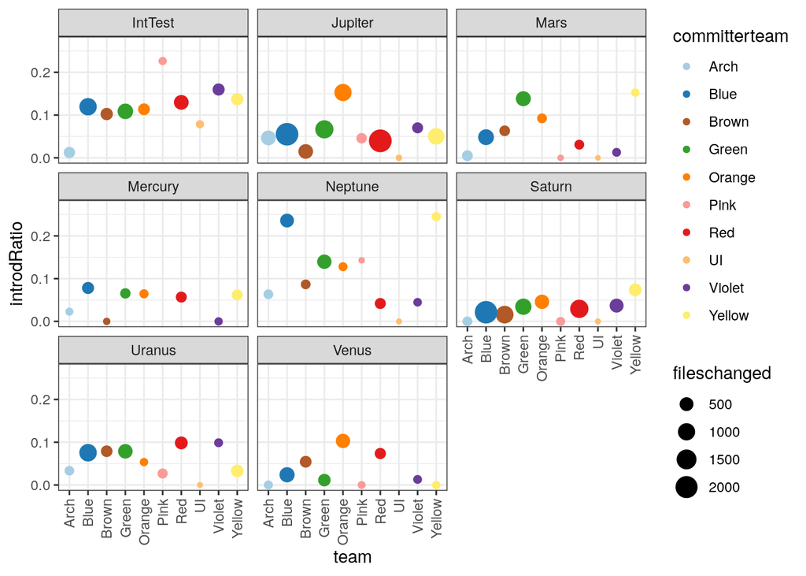

```r
changesPerRepoAndTeam <- data |> group_by(repo, committerteam) |> summarise(fileschanged=n())
zerosPerRepoAndTeam <- data |> filter(INTROD == 0) |> group_by(repo, committerteam) |> summarise(zeros=n())
zeros_ratio <- merge(changesPerRepoAndTeam, zerosPerRepoAndTeam) |> mutate(introdRatio = 1-(zeros/fileschanged)) |> arrange(introdRatio)

(p <- zeros_ratio |> filter(committerteam != "Unknown") |> ggplot(aes(x=committerteam, y=introdRatio, color=committerteam, size=fileschanged)) + geom_point() + facet_wrap(~ repo) + xlab("team") + scale_color_manual(values=COLOR_BY_TEAM) + theme_bw() + scale_y_continuous(limits=c(0,0.27)) + theme(axis.text.x = element_text(angle = 90, vjust = 0.5, hjust=1))
)
```

```r
figsave("99-observed_proportion_dup_per_repo_team.pdf", p)
```

## Figure 7 - OCAM metrics for Jupiter and Uranus repositories

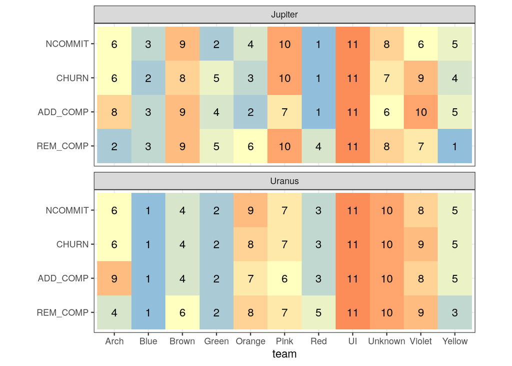

```r
(ocam_plot <- ocam_rank_repo(ocam_metrics(data) |> filter(repo %in% c(JUPITER, URANUS))) + theme_bw() + theme(legend.position = "none") + ylab(NULL)
)
```

```r
figsave("99-ocam_jupiter_uranus.pdf", ocam_plot)
```

```r
source("predict_utils.R")
```

## Figure 8 - Number of changes that introduce particular number of clones in Jupiter for four teams

Observed number of changes that introduce a particular number of duplicate

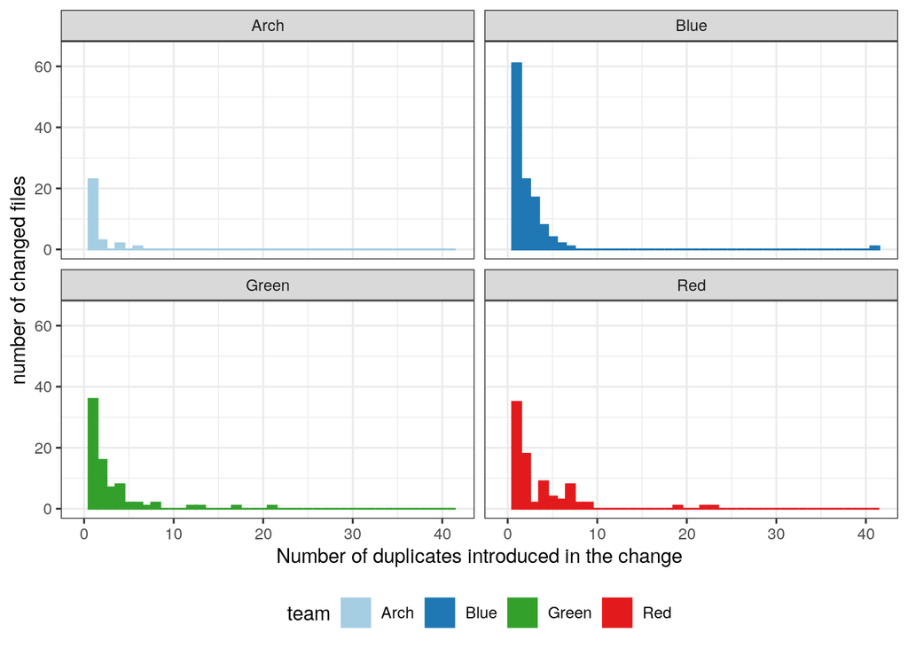

```r
plot_introd_issues_in_repo <- function(aRepo, team_selector) {
  data |> filter(repo == aRepo, team_selector(committerteam)) |> mutate(team = committerteam) |> group_by(team) |> ggplot(aes(x=INTROD, color=team, fill=team)) + geom_histogram(binwidth = 1) + facet_wrap(~ team) + scale_fill_manual(name="team", values=teamcolors) + scale_colour_manual(name="team", values=teamcolors) + ylab("number of changed files") + xlab("Number of duplicates introduced in the change") + ylim(0,65)
}
(p <- plot_introd_issues_in_repo(JUPITER, function(x) x %in% c(RED, BLUE, GREEN, ARCH)) + theme_bw() + theme(legend.position = "bottom"))
```

```r
figsave("99-observed-INTROD-4teams-Jupiter.pdf", p)
```

## Figure 9 - Posterior predicted 99th percentile per team

Note that we already calculated yrep (from M2) above, so we’ll just reuse it here.

```r
(p <- ppc_stat_grouped(y = d$y, yrep, stat = "q99", group = d$team) + ggtitle("Posterior predictive 99% quartile per team")
)
```

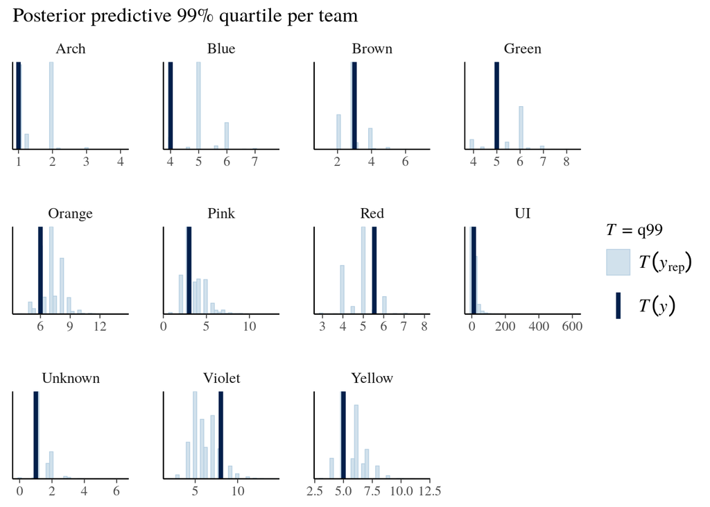

```r
figsave("99-posterior-q99-teams.pdf", p)
```

## Figure 10 - Probability of one or more duplicates for a large change in a complex file

```r
duplicates_probability <- function(predictions) {
  params = predictions |> select(added, removed, complexity, duplicates) |> distinct()
  stopifnot(length(params$added) == 1)
  predictions |> ggplot(aes(x=team, y=pred0/100, color=team)) + geom_boxplot() + facet_wrap(~ repo) + scale_color_manual(values=COLOR_BY_TEAM) + theme_bw() + ggtitle("Probability of any duplicate per team and repository", paste("added", params$added, "removed", params$removed, "complexity", params$complexity, "duplicates", params$duplicates)) + theme(axis.text.x = element_text(angle = 90, vjust = 0.5, hjust=1)) + ylab("P(INTROD > 0)")
}

more_five_probability <- function(predictions) {
  params = predictions |> select(added, removed, complexity, duplicates) |> distinct()
  stopifnot(length(params$added) == 1)
  predictions |> ggplot(aes(x=team, y=pred5/100, color=team)) + geom_boxplot() + facet_wrap(~ repo) + scale_color_manual(values=COLOR_BY_TEAM) + theme_bw() + ggtitle("Probability of more than five duplicates per team and repository", paste("added", params$added, "removed", params$removed, "complexity", params$complexity, "duplicates", params$duplicates)) + theme(axis.text.x = element_text(angle = 90, vjust = 0.5, hjust=1)) + ylab("P(INTROD > 5)")
}
```

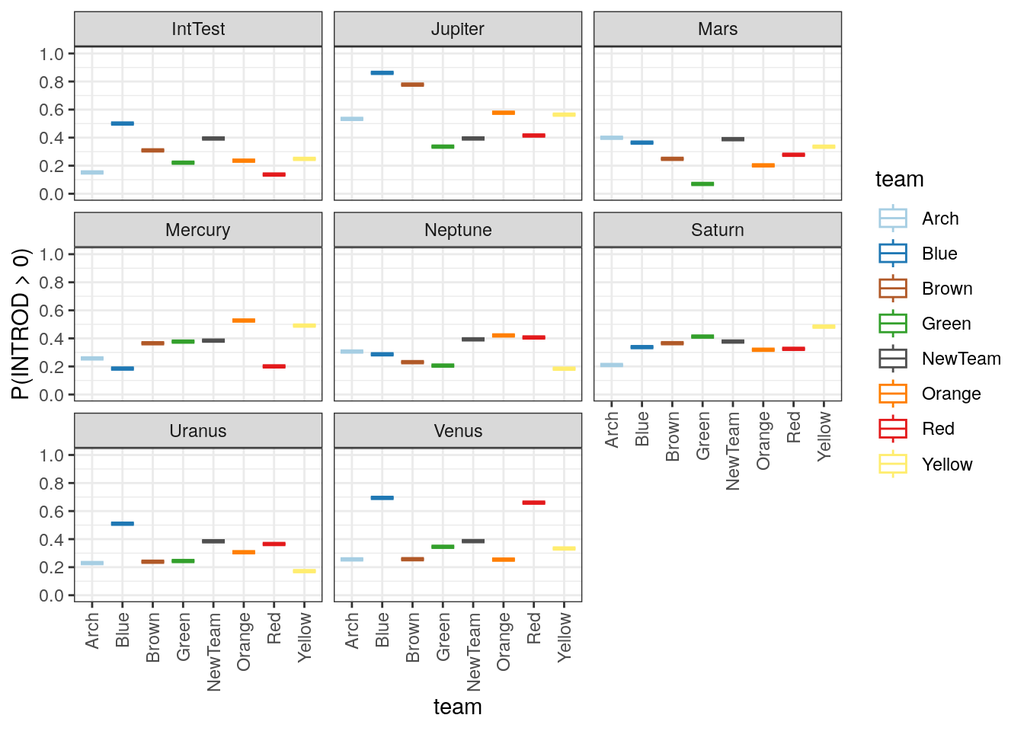

```r
pred <- onepred(model=M2, added=q99(data$ADD), removed=q99(data$DEL), complexity = q95(data$COMPLEX), duplicates=q95(data$DUP))
(p <- duplicates_probability(pred) + ggtitle(label=NULL, subtitle=NULL) + scale_y_continuous(limits=c(0,1), breaks=c(0, 0.2, 0.4, 0.6, 0.8, 1.0)))
```

```r
figsave("99-prob_duplicates_large_complex_change.pdf", p)
```

```r
source("conditional_effects.R")
```

## Figure 11 - Comparing Blue&Red in Jupiter&Uranus

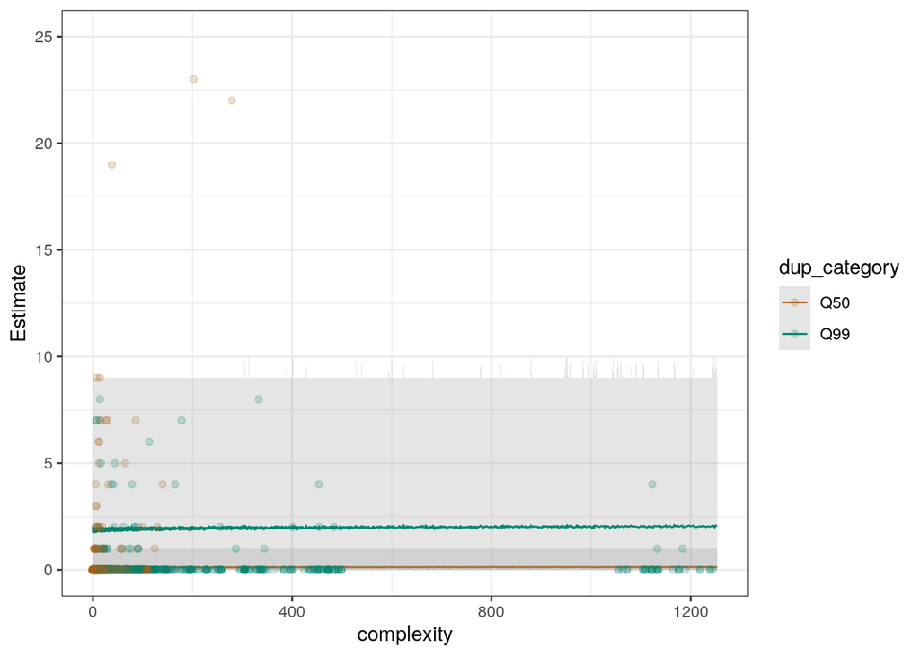

```r
(red_jupiter_plot <- plot_logCOMPLEX_by_logDUP_median_q99(M2, d, condeffect_logCOMPLEX_by_logDUP_median_q99(M2, d, RED, JUPITER, added=q95(data$ADD), removed=q95(data$DEL)), RED, JUPITER) +
   scale_color_manual(values=c(Q50=rgb(166,97,26, maxColorValue = 255),Q99=rgb(1, 133, 113, maxColorValue = 255))) +
   labs(title=NULL, subtitle=NULL, legend=NULL) + scale_x_continuous(limits=c(0,max(data$COMPLEX)+10)) + theme_bw() +  scale_y_continuous(limits=c(0,25))
)
```

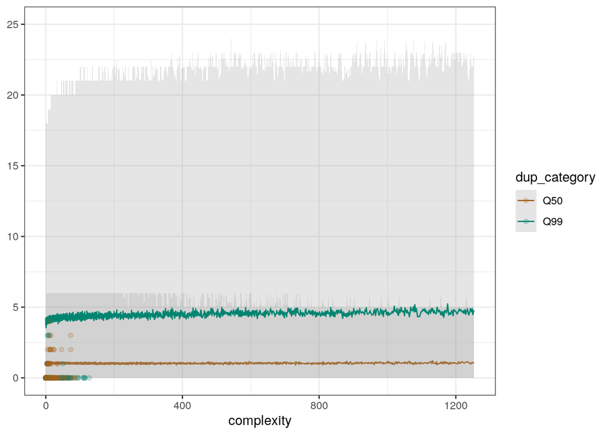

```r
(red_uranus_plot <- plot_logCOMPLEX_by_logDUP_median_q99(M2, d, condeffect_logCOMPLEX_by_logDUP_median_q99(M2, d, RED, URANUS, added=q95(data$ADD), removed=q95(data$DEL)), RED, URANUS) + labs(title=NULL, subtitle=NULL) +
   scale_color_manual(values=c(Q50=rgb(166,97,26, maxColorValue = 255),Q99=rgb(1, 133, 113, maxColorValue = 255))) +
   scale_x_continuous(limits=c(0,max(data$COMPLEX)+10)) + theme_bw() + ylab(NULL) + scale_y_continuous(limits=c(0,25))
)
```

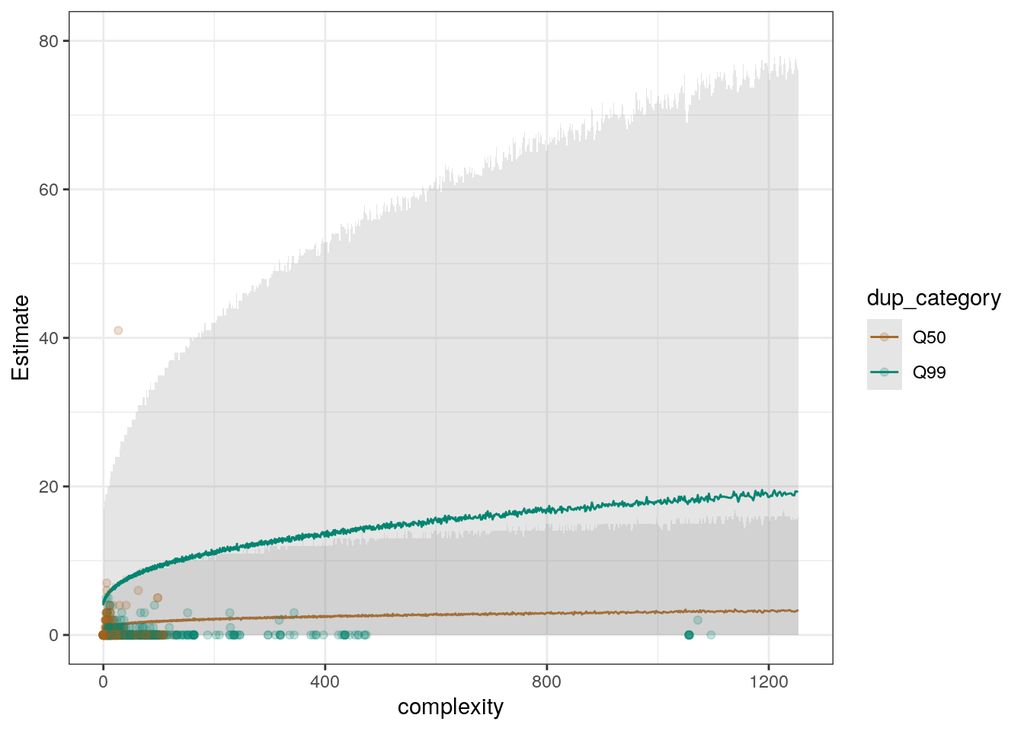

```r
(blue_jupiter_plot <- plot_logCOMPLEX_by_logDUP_median_q99(M2, d, condeffect_logCOMPLEX_by_logDUP_median_q99(M2, d, BLUE, JUPITER, added=q95(data$ADD), removed=q95(data$DEL)), BLUE, JUPITER) + labs(title=NULL, subtitle=NULL) +
   scale_color_manual(values=c(Q50=rgb(166,97,26, maxColorValue = 255),Q99=rgb(1, 133, 113, maxColorValue = 255))) +
   scale_x_continuous(limits=c(0,max(data$COMPLEX)+10)) + scale_y_continuous(limits=c(0,80)) + theme(legend.position = "none") + theme_bw()
)
```

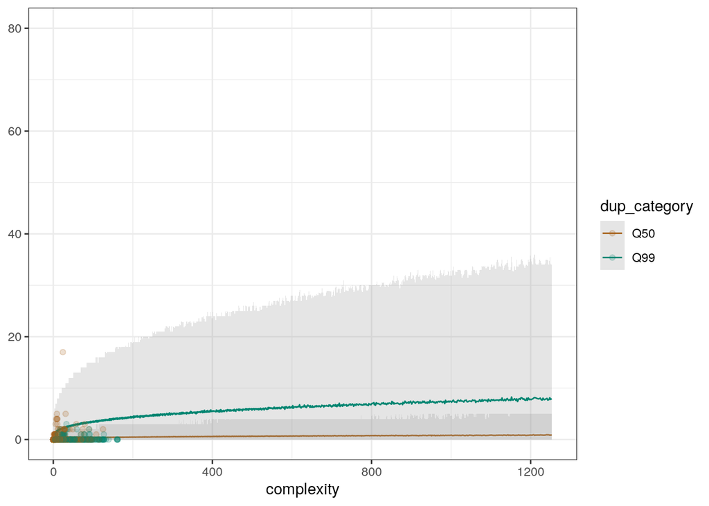

```r
(blue_uranus_plot <- plot_logCOMPLEX_by_logDUP_median_q99(M2, d, condeffect_logCOMPLEX_by_logDUP_median_q99(M2, d, BLUE, URANUS, added=q95(data$ADD), removed=q95(data$DEL)), BLUE, URANUS) + labs(title=NULL, subtitle=NULL) +
   scale_color_manual(values=c(Q50=rgb(166,97,26, maxColorValue = 255),Q99=rgb(1, 133, 113, maxColorValue = 255))) +
   scale_x_continuous(limits=c(0,max(data$COMPLEX)+10)) + scale_y_continuous(limits=c(0,80)) + ylab(NULL) + theme_bw()
)
```

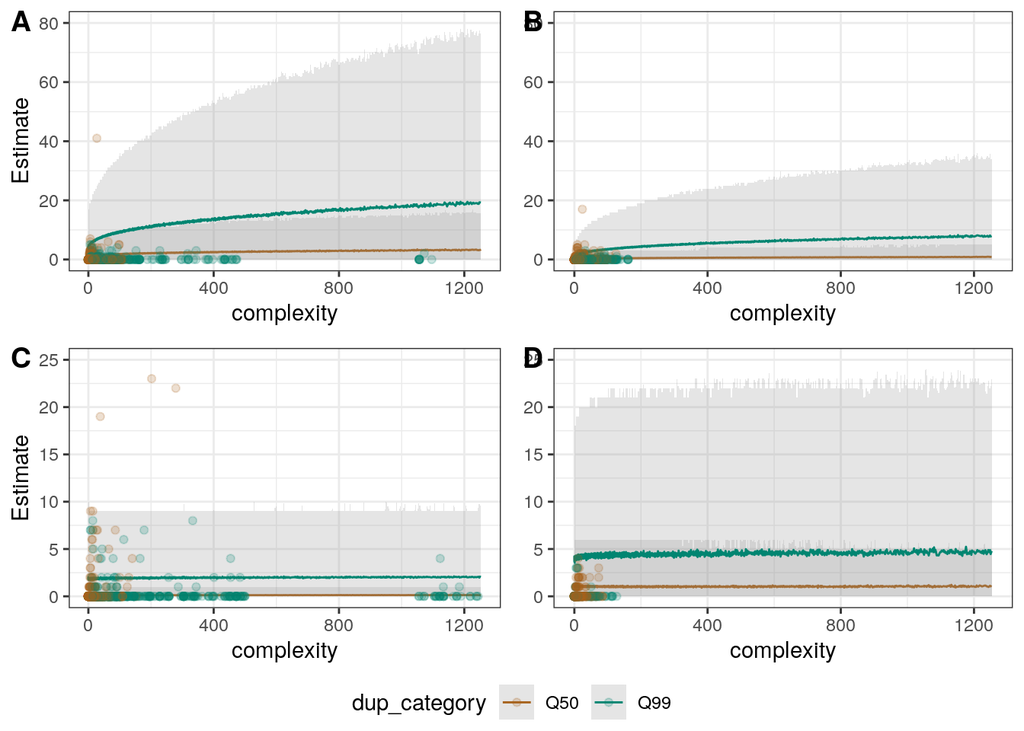

```r
(complexity_plot <- ggarrange(plotlist = list(blue_jupiter_plot, blue_uranus_plot, red_jupiter_plot, red_uranus_plot), labels="AUTO", nrow=2, ncol=2, common.legend = T, legend="bottom")
 )
```

```r
figsave("99-blue_red_complexity.pdf", complexity_plot)
```

## Figure 12 - Probability of clones

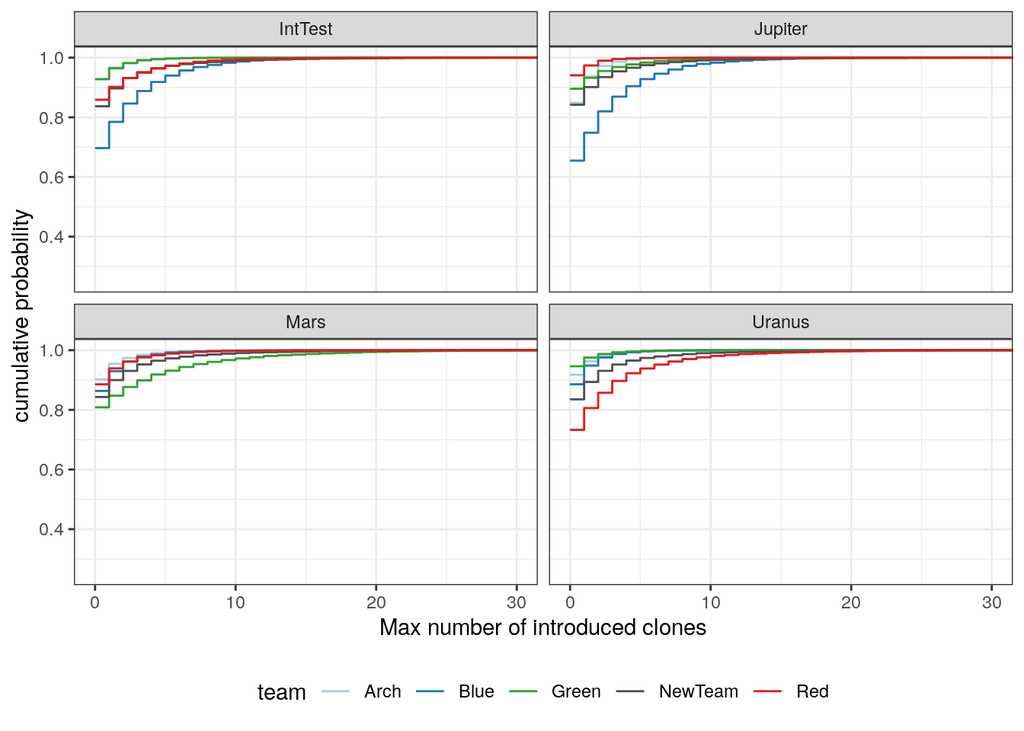

```r
(median_plot <- plot_cumulative_prob_of_duplicates(predict_for_team(M2, c(ARCH, BLUE, RED, NEWTEAM, GREEN), repo=c(URANUS, JUPITER, INTTEST, MARS), added=q95(data$ADD), removed=q95(data$DEL), duplicates=median(data$DUP), complex=median(data$COMPLEX))) + scale_y_continuous(limits = c(0.25,1.0)) + scale_x_continuous(limits = c(0,30))+ ggtitle(label=NULL, subtitle=NULL) + theme(legend.position = "bottom") + ylab("cumulative probability") + xlab("Max number of introduced clones")
)
```

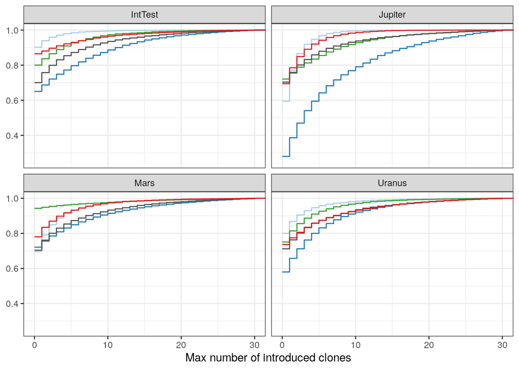

```r
(q95_plot <- plot_cumulative_prob_of_duplicates(predict_for_team(M2, c(ARCH, BLUE, RED, NEWTEAM, GREEN), repo=c(URANUS, JUPITER, INTTEST, MARS), added=q95(data$ADD), removed=q95(data$DEL), duplicates=q95(data$DUP), complex=q95(data$COMPLEX))) + scale_y_continuous(limits = c(0.25,1.0)) + scale_x_continuous(limits = c(0,30))+ ggtitle(label=NULL, subtitle=NULL) + theme(legend.position = "none") + ylab(NULL)  + xlab("Max number of introduced clones")
)
```

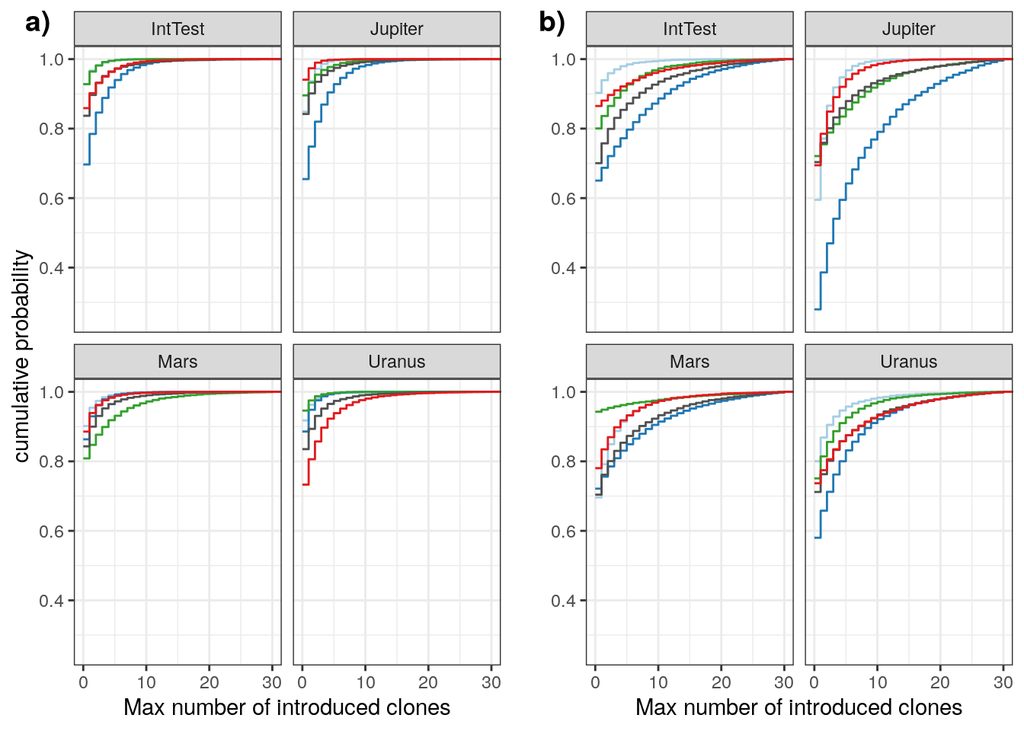

```r
(prow <- plot_grid(median_plot + theme(legend.position = "none"), q95_plot, align = "hv", labels=c("a)", "b)"), hjust=-1, nrow=1))
```

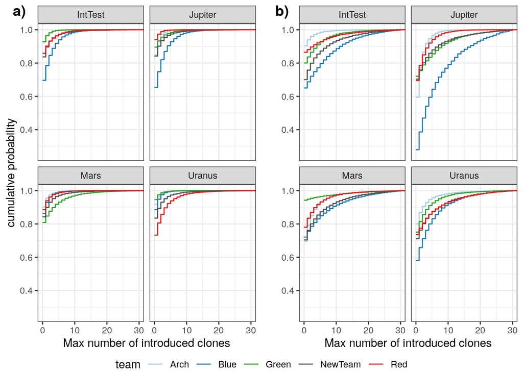

```r
legend <- get_legend(median_plot)
(p <- plot_grid(prow, legend, ncol=1, rel_heights = c(1,.05))
)
```

```r
figsave("99-predicted_median_vs_q95.pdf", p)
```

## Figure 13 - Removals

As the model has no predictors, just intercepts, it does not matter what values are used. But our onepred function will use them anyway, with the default values, so the data frame will include them. But they are not used to make inferences.

```r
(p <- removals_probability(onepred(model=RM0)) + ggtitle(label=NULL, subtitle=NULL)
)
```

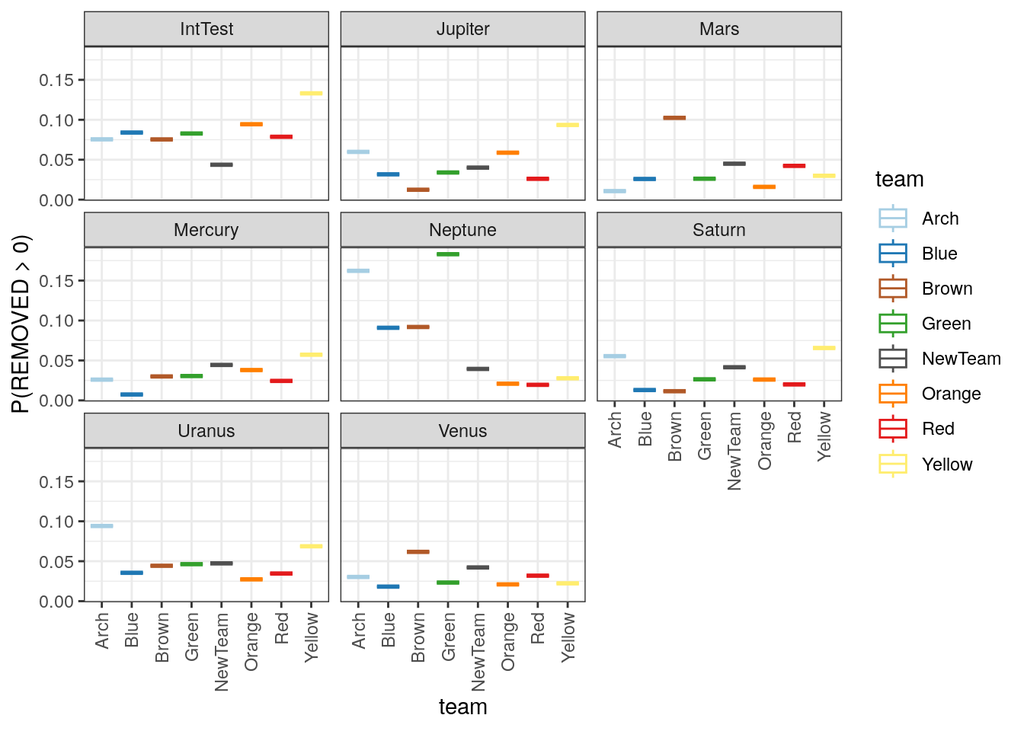

```r
figsave("99-prob-REMOVE-intercept-by-team.pdf", p)
```